# çda proje

### 1. Veri Setine Genel Bakışı:

Uyku Sağlığı ve Yaşam Tarzı Veri Seti, uyku ve günlük alışkanlıklarla ilgili çok çeşitli değişkenleri kapsayan 374 satır ve 13 sütundan oluşur. Cinsiyet, yaş, meslek, uyku süresi, uyku kalitesi, fiziksel aktivite seviyesi, stres seviyeleri, BMI kategorisi, kan basıncı, kalp hızı, günlük adımlar ve uyku bozukluklarının varlığı veya yokluğu gibi ayrıntıları içerir.

### Veri Seti Sütunları:

> - Kişi Kimliği: Her bir birey için bir tanımlayıcı.
> - Cinsiyet: Kişinin cinsiyeti (Erkek/Kadın).
> - Yaş: Kişinin yıl cinsinden yaşı.
> - Meslek: Kişinin mesleği veya işi.
> - Uyku Süresi (saat): Kişinin günde uyuduğu saat sayısı.
> - Uyku Kalitesi (ölçek: 1-10): Uyku kalitesinin 1 ile 10 arasında değişen öznel bir değerlendirmesi.
> - Fiziksel Aktivite Seviyesi (dakika/gün): Kişinin günlük olarak fiziksel aktivitede bulunduğu dakika sayısı.
> - Stres Seviyesi (ölçek: 1-10): Kişinin deneyimlediği stres seviyesinin 1 ile 10 arasında değişen öznel bir değerlendirmesi.
> - BMI Kategorisi: Kişinin BMI kategorisi (örn. Düşük Kilolu, Normal, Fazla Kilolu).
> - Kan Basıncı (sistolik/diyastolik): Kişinin kan basıncı ölçümü, sistolik basıncın diyastolik basınca oranı olarak gösterilir.
> - Kalp Hızı (bpm): Kişinin dinlenme kalp hızı, dakikadaki atış sayısı cinsinden.
> - Günlük Adım Sayısı: Kişinin günde attığı adım sayısı.
> - Uyku Bozukluğu: Kişide uyku bozukluğunun varlığı veya yokluğu (Yok, Uykusuzluk, Uyku Apnesi).

### Uyku Bozukluğu Sütunu Hakkında Detaylar:

> - Yok: Kişide spesifik bir uyku bozukluğu görülmemektedir.
> - Uyku bozukluğu: Kişi uykuya dalmada veya uykuyu sürdürmede zorluk yaşar, bu da yetersiz veya kalitesiz uykuya yol açar.
> - Uyku Apnesi: Kişinin uyku sırasında solunum durması sonucu uyku düzeninin bozulması ve potansiyel sağlık risklerinin ortaya çıkmasıdır.

## 2. VERİ ANALİZİ

## 2.1 Verinin yüklenmesi

```r
library(readr)
veri <- read_delim("veri.csv", delim = ",",
    escape_double = FALSE, trim_ws = TRUE)
View(veri)
```

### 2.2 Boş veri kontrolü

```r
bos_veri<- is.na(veri)
sum(bos_veri)
```

```
## [1] 0
```

Boş veri bulunmamaktadır.

### 2.3 Veri hakkında genel bilgiler ve veriyi tanımlayan grafikler

```r
str(veri)
```

```
## spc_tbl_ [374 × 13] (S3: spec_tbl_df/tbl_df/tbl/data.frame)
##  $ Person ID              : num [1:374] 1 2 3 4 5 6 7 8 9 10 ...
##  $ Gender                 : chr [1:374] "Male" "Male" "Male" "Male" ...
##  $ Age                    : num [1:374] 27 28 28 28 28 28 29 29 29 29 ...
##  $ Occupation             : chr [1:374] "Software Engineer" "Doctor" "Doctor" "Sales Representative" ...
##  $ Sleep Duration         : num [1:374] 6.1 6.2 6.2 5.9 5.9 5.9 6.3 7.8 7.8 7.8 ...
##  $ Quality of Sleep       : num [1:374] 6 6 6 4 4 4 6 7 7 7 ...
##  $ Physical Activity Level: num [1:374] 42 60 60 30 30 30 40 75 75 75 ...
##  $ Stress Level           : num [1:374] 6 8 8 8 8 8 7 6 6 6 ...
##  $ BMI Category           : chr [1:374] "Overweight" "Normal" "Normal" "Obese" ...
##  $ Blood Pressure         : chr [1:374] "126/83" "125/80" "125/80" "140/90" ...
##  $ Heart Rate             : num [1:374] 77 75 75 85 85 85 82 70 70 70 ...
##  $ Daily Steps            : num [1:374] 4200 10000 10000 3000 3000 3000 3500 8000 8000 8000 ...
##  $ Sleep Disorder         : chr [1:374] "None" "None" "None" "Sleep Apnea" ...
##  - attr(*, "spec")=
##   .. cols(
##   ..   `Person ID` = col_double(),
##   ..   Gender = col_character(),
##   ..   Age = col_double(),
##   ..   Occupation = col_character(),
##   ..   `Sleep Duration` = col_double(),
##   ..   `Quality of Sleep` = col_double(),
##   ..   `Physical Activity Level` = col_double(),
##   ..   `Stress Level` = col_double(),
##   ..   `BMI Category` = col_character(),
##   ..   `Blood Pressure` = col_character(),
##   ..   `Heart Rate` = col_double(),
##   ..   `Daily Steps` = col_double(),
##   ..   `Sleep Disorder` = col_character()
##   .. )
##  - attr(*, "problems")=<externalptr>
```

### 2.3 Sayısal Veriler Hakkında Sütun Grafikleri

```r
library(funModeling)
```

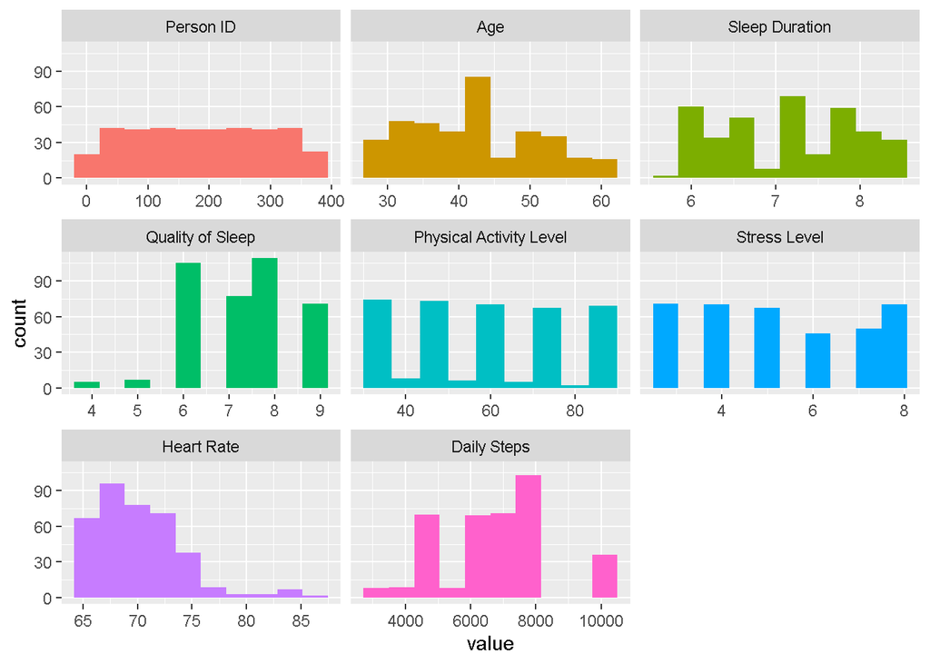

```r
plot_num(veri)
```

## 3 Değişkenlerin Çarpıklık ve Basıklık İncelemeleri

### 3.1 Age değişkeni için çarpıklık ve basıklık

```r
library(e1071)
skewness(veri$Age)
```

```
## [1] 0.2551625
```

```r
kurtosis(veri$Age)
```

```
## [1] -0.9248041
```

Age değişkeni için sağa çarpık, basıklık için ise mutlak değerce 3’ten küçük olduğu için basık ifadeleri kullanılabilir.

### 3.2 Sleep Duration değişkeni için çarpıklık ve basıklık

```r
skewness(veri$`Sleep Duration`)
```

```
## [1] 0.03725369
```

```r
kurtosis(veri$`Sleep Duration`)
```

```
## [1] -1.294528
```

Sleep Duration değişkeni için hafif sağa çarpık, basıklık için ise mutlak değerce 3’ten küçük olduğu için basık ifadeleri kullanılabilir.

### 3.3 Quality of Sleep değişkeni için çarpıklık ve basıklık

```r
skewness(veri$`Quality of Sleep`)
```

```
## [1] -0.2057866
```

```r
kurtosis(veri$`Quality of Sleep`)
```

```
## [1] -0.7663022
```

Quality of Sleep değişkeni için sola çarpık, basıklık için ise mutlak değerce 3’ten küçük olduğu için basık ifadeleri kullanılabilir.

### 3.4Physical Activity Level değişkeni için çarpıklık ve basıklık

```r
skewness(veri$`Physical Activity Level`)
```

```
## [1] 0.07389048
```

```r
kurtosis(veri$`Physical Activity Level`)
```

```
## [1] -1.27447
```

Physical Activity Level değişkeni için sağa çarpık, basıklık için ise mutlak değerce 3’ten küçük olduğu için basık ifadeleri kullanılabilir.

### 4. Cinsiyet için pasta grafiği

```r
cinsiyet <- table(veri$Gender)
cinsiyet_df <- data.frame(cinsiyet = names(cinsiyet), sayi = as.numeric(cinsiyet))
cinsiyet_df$yuzde <- round(cinsiyet_df$sayi / sum(cinsiyet_df$sayi) * 100, 1)
```

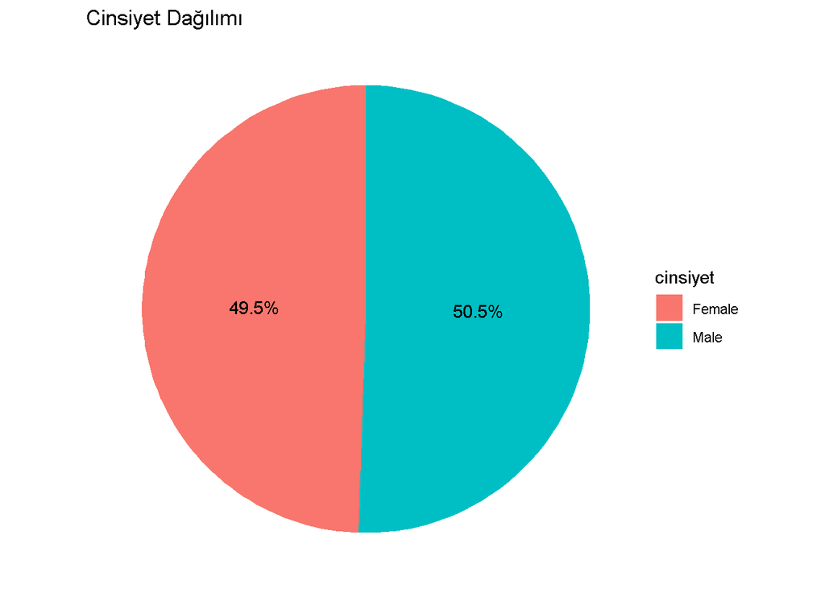

```r
library(ggplot2)
ggplot(cinsiyet_df, aes(x = "", y = sayi, fill = cinsiyet)) +
  geom_bar(width = 1, stat = "identity") +
  coord_polar("y", start = 0) +
  labs(title = "Cinsiyet Dağılımı") +
  geom_text(aes(label = paste0(yuzde, "%")), position = position_stack(vjust = 0.5)) +
  theme_void()
```

### 5. Heart Rate değişkeni için box plot grafiği

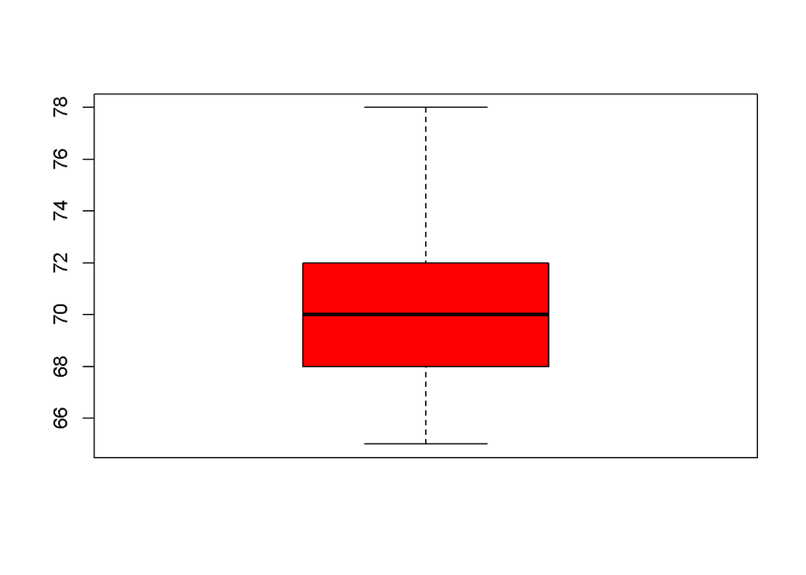

```r
boxplot(veri$`Heart Rate`, notch = FALSE, outline = FALSE, horizontal = FALSE, col = "red")
```

### 5.1 Daily Steps değişkeni için box plot grafiği

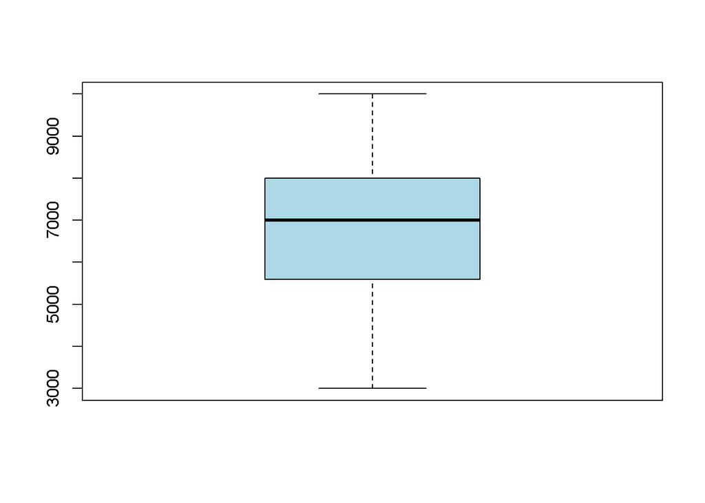

```r
boxplot(veri$`Daily Steps`, notch = FALSE, outline = FALSE, horizontal = FALSE, col = "lightblue")
```

## 6. NORMAL DAĞILIM TESTİ

### 6.1 AGE

```r
ks.test(veri$Age, "pnorm", mean(veri$Age), sd(veri$Age))
```

```
##
##  Asymptotic one-sample Kolmogorov-Smirnov test
##
## data:  veri$Age
## D = 0.085546, p-value = 0.008389
## alternative hypothesis: two-sided
```

HO: Age değişkeni normal dağılmaktadır. HA: Age değişkeni normal dağılmamaktadır. p= 0.008389 < 0.05 Ho RED EDİLİR. Değişken normal dağılmamaktadır. AGE değişkeni için dönüşüm, SPSS uygulaması üzerinden yapılacaktır.

### 6.2 SLEEP DURATİON

```r
ks.test(veri$`Sleep Duration`, "pnorm", mean(veri$`Sleep Duration`), sd(veri$`Sleep Duration`))
```

```
##
##  Asymptotic one-sample Kolmogorov-Smirnov test
##
## data:  veri$`Sleep Duration`
## D = 0.12785, p-value = 9.802e-06
## alternative hypothesis: two-sided
```

HO: SLEEP DURATİON değişkeni normal dağılmaktadır. HA: SLEEP DURATİON değişkeni normal dağılmamaktadır. p= 9.802e-06 < 0.05 Ho RED EDİLİR. Değişken normal dağılmamaktadır. SLEEP DURATİON değişkeni için dönüşüm, SPSS uygulaması üzerinden yapılacaktır.

### 6..3 Quality of Sleep

```r
ks.test(veri$`Quality of Sleep`, "pnorm", mean(veri$`Quality of Sleep`), sd(veri$`Quality of Sleep`))
```

```
##
##  Asymptotic one-sample Kolmogorov-Smirnov test
##
## data:  veri$`Quality of Sleep`
## D = 0.19833, p-value = 3.333e-13
## alternative hypothesis: two-sided
```

HO: Quality of Sleep değişkeni normal dağılmaktadır. HA: Quality of Sleep değişkeni normal dağılmamaktadır. p= 3.333e-13< 0.05 Ho RED EDİLİR. Değişken normal dağılmamaktadır. Quality of Sleep değişkeni için dönüşüm, SPSS uygulaması üzerinden yapılacaktır.

### 6.4 Physical Activity Level

```r
ks.test(veri$`Physical Activity Level`, "pnorm", mean(veri$`Physical Activity Level`), sd(veri$`Physical Activity Level`))
```

```
##
##  Asymptotic one-sample Kolmogorov-Smirnov test
##
## data:  veri$`Physical Activity Level`
## D = 0.15291, p-value = 5.074e-08
## alternative hypothesis: two-sided
```

HO: Physical Activity Level değişkeni normal dağılmaktadır. HA: Physical Activity Level değişkeni normal dağılmamaktadır. p= 5.074e-08 < 0.05 Ho RED EDİLİR. Değişken normal dağılmamaktadır. Physical Activity Level değişkeni için dönüşüm, SPSS uygulaması üzerinden yapılacaktır.

### 6.5 Stress Level

```r
ks.test(veri$`Stress Level`, "pnorm", mean(veri$`Stress Level`), sd(veri$`Stress Level`))
```

```
##
##  Asymptotic one-sample Kolmogorov-Smirnov test
##
## data:  veri$`Stress Level`
## D = 0.15946, p-value = 1.099e-08
## alternative hypothesis: two-sided
```

HO: Stress Level değişkeni normal dağılmaktadır. HA: Stress Level değişkeni normal dağılmamaktadır. p= 1.099e-08 < 0.05 Ho RED EDİLİR. Değişken normal dağılmamaktadır. Stress Level değişkeni için dönüşüm, SPSS uygulaması üzerinden yapılacaktır.

### 6.6 Heart Rate

```r
ks.test(veri$`Heart Rate`, "pnorm", mean(veri$`Heart Rate`), sd(veri$`Heart Rate`))
```

```
##
##  Asymptotic one-sample Kolmogorov-Smirnov test
##
## data:  veri$`Heart Rate`
## D = 0.16037, p-value = 8.833e-09
## alternative hypothesis: two-sided
```

HO: Heart Rate değişkeni normal dağılmaktadır. HA: Heart Rate değişkeni normal dağılmamaktadır. p= 8.833e-09 < 0.05 Ho RED EDİLİR. Değişken normal dağılmamaktadır. Heart Rate değişkeni için dönüşüm, SPSS uygulaması üzerinden yapılacaktır.

### 6.7 Daily Steps

```r
ks.test(veri$`Daily Steps`, "pnorm", mean(veri$`Daily Steps`), sd(veri$`Daily Steps`))
```

```
##
##  Asymptotic one-sample Kolmogorov-Smirnov test
##
## data:  veri$`Daily Steps`
## D = 0.13605, p-value = 1.943e-06
## alternative hypothesis: two-sided
```

HO: Daily Steps değişkeni normal dağılmaktadır. HA: Daily Steps değişkeni normal dağılmamaktadır. p= 1.943e-06 < 0.05 Ho RED EDİLİR. Değişken normal dağılmamaktadır. Daily Steps değişkeni için dönüşüm, SPSS uygulaması üzerinden yapılacaktır.